# Gulf of Mexico well interventions: the life of a well (revision 4)

[figure not shown]

## What changed since revision 2 (review copy; not printed)

- **Opening graphic** (road map note, 13 November: "add the deckhand opening graphic to each of the newsletters"): the shared Deckhand opening graphic heads the page; its slot carries this article's title, with no chart.
- **Why interventions matter, first** (comment 1): section 1 opens the article; its cost detail is in Appendix B.
- **The life story of a well, before the interventions** (comment 2): section 2, with Figures 1 and 2 and Table 1, comes before Figure 3.
- **What the rate means** (comment 3): section 3, "What the rate means", under Figure 4; the light and heavy detail is in Appendix C.
- **Abandonment in the next article** (comment 2): counted and rated here; section 5 says the next article covers it.
- **Across all articles and worldwide wells** (general comment): not in this article; passed on for planning.

The Deckhand Chronicles is AceEngineer's newsletter. We help build AI into everyday engineering work.

Energy Street · Well interventions

# Gulf of Mexico well interventions: the life of a well, then the work by water depth

> A Gulf of Mexico development well lives about 23.0 years from first spud to permanent abandonment. The data hold 16,860 development wells abandoned so far, of which 16,858 have an established life; the 23.0-year median is over those 16,858. Across today's wells, heavy work with a rig or a hydraulic workover unit comes at a median 13.3 years after spud, and light wireline and coiled-tubing work later, at 24.1 years. The 23.0-year life and the 33.0-year median age at permanent-abandonment approval describe different populations: the first is the life of those abandoned wells, the second the age of the well at 17,904 permanent-abandonment approvals from 2005 to 2026, and counts approvals, not wells: a well approved twice counts twice, and a well still standing can count. In 2025, BSEE approved 765 interventions and 2,610 abandonments; per standing well, interventions are seven times as frequent at 1,500 m and deeper as on the shelf (under 100 m water depth): 38.7 against 5.5 approvals per 100 wells.

Revision 4, 14 November 2026. Data: BSEE raw well data, files of 13 November 2026. [Read the full study](https://github.com/vamseeachanta/worldenergydata/tree/24744b528298f26c51bfce4cb3b66fa4f676eb02/examples/bsee/interventions_by_depth).

**In this article**

1. Why interventions matter
2. The life of a Gulf of Mexico well
3. Interventions by water depth
4. Cost per intervention, by access type
5. Abandonment
6. Charts and data

## 1. Why interventions matter

A well intervention is any job that goes back into a completed well to keep it producing. The Bureau of Ocean Energy Management (BOEM) says producing wells "may require periodic reentry that is designed to maintain or restore a desired flow rate" ([BOEM 2016-018](https://www.boem.gov/sites/default/files/environmental-stewardship/Environmental-Assessment/NEPA/BOEM-EIS-2016-018-v1.pdf), section 3.1.3.5, p. 3-37) and expects "seven workovers or other well activities during its lifetime" (p. 3-38).

**Light and heavy.** A light intervention works through the tubing with wireline or coiled tubing, without a rig; a heavy one brings in a rig or a hydraulic workover unit that can pull the tubing. On a subsea well, a workover "require[s] that a rig be moved on location" (BOEM, p. 3-37); intervention vessels are "very cost effective in decommissioning subsea wells compared to using a drilling rig" ([BSEE TAP-738](https://www.bsee.gov/sites/bsee.gov/files/tap-technical-assessment-program/738aa1.pdf), 2015, p. 5-21).

**What it costs and saves.** In our scenarios, built from TAP-738 day rates and BOEM durations (2015 dollars; Appendix B), a light well-work job on a shelf platform costs USD 0.53 to 0.98 million and a subsea job from a drillship or semisubmersible USD 4.7 to 9.4 million. A vessel saves rig days: eight to 10 days against 12 to 15 with a rig (TAP-738, p. 6-9).

## 2. The life of a Gulf of Mexico well

BSEE's borehole file and permits to modify give each well a life story. Of the 37,512 Gulf wells with a spud date, 30,737 are permanently abandoned and 6,775 still stand.

Figure 1 shows how long wells last, development and exploration, abandoned and still standing.

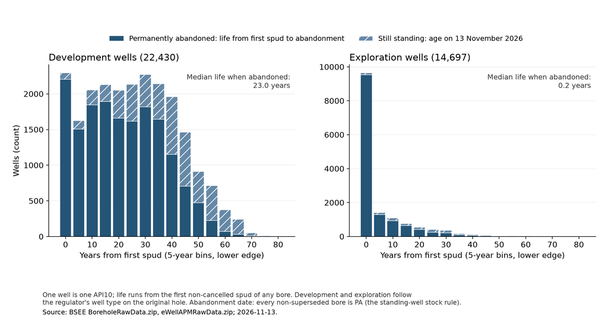

Figure 1. How long Gulf of Mexico wells last

1. One well is one API10 number. Life runs from the first non-cancelled spud of any of its bores to permanent abandonment (every bore that is not superseded by a sidetrack or bypass is permanently abandoned, at the latest such date), or to 13 November 2026 for a well still standing. 17 wells without a spud date and 8 with an abandonment date before spud are left out.

2. Development and exploration follow the regulator's well type on the original hole. Wells of other or no stated type are counted in the totals and not shown.

3. Source: BSEE borehole and permit-to-modify raw data, files of 13 November 2026. Data: life_cycle_life_histogram.csv, life_cycle_life_years.csv.

- Exploration wells have short lives: 8,583 of the 13,537 abandoned ones were plugged within a year of spud (median 0.2 years).
- Abandoned development wells lived a median 23.0 years, the middle half between 11.3 and 35.3; the 5,570 still standing are a median 42.0 years old.

Figure 2 shows the share of wells reaching each stage and the well's age at each kind of work.

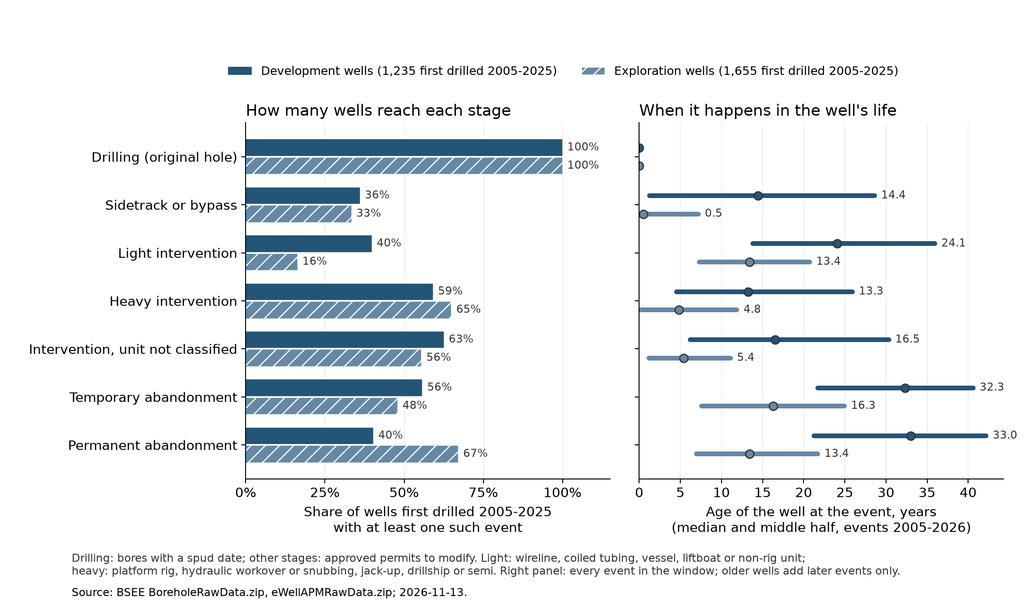

Figure 2. The life of a well, stage by stage

1. Left: wells first drilled from 2005 to 2025, whose whole life lies inside the permit record (1,235 development and 1,655 exploration wells). A stage is reached when the well has at least one bore or approved permit of that kind up to 13 November 2026.

2. Light: the permit names a wireline unit, coiled tubing, an intervention vessel, a liftboat or a recorded non-rig operation. Heavy: a platform rig, a hydraulic workover or snubbing unit, a jack-up rig, a drillship or a semisubmersible. Not classified: no unit or another unit type is named (Appendix A).

3. Right: age of the well, in years after first spud, at every sidetrack or bypass spud and every approved permit from 2005 to 13 November 2026, for all wells. Older wells add only their later events, so the panel shows when this work happens across today's wells, not one well followed from birth.

4. Data: life_cycle_stage_reach.csv, life_cycle_event_ages.csv; reconciliation with the permit counts: life_cycle_reconciliation.csv.

| Per well | Development, first drilled 2005-2025 | Exploration, first drilled 2005-2025 |
| --- | --- | --- |
| Wells | 1,235 | 1,655 |
| Bores drilled per well (original hole plus sidetracks and bypasses) | 1.56 | 1.53 |
| Light intervention approvals per well | 1.34 | 0.61 |
| Heavy intervention approvals per well | 1.57 | 1.39 |
| Intervention approvals, unit not classified, per well | 1.28 | 1.15 |
| All intervention approvals per well | 4.18 | 3.15 |
| Temporary abandonment approvals per well | 1.35 | 1.08 |
| Permanent abandonment approvals per well | 0.85 | 1.33 |
| Permanently abandoned by 13 November 2026 | 39% | 68% |
| Median life of those abandoned (years) | 9.2 | 0.6 |
| Median age of those standing (years) | 14.4 | 12.2 |

Table 1. A Gulf of Mexico well in numbers

1. Wells first drilled from 2005 to 2025; counts run to 13 November 2026, so a young well has had less time for work than an old one. Per-well figures are means; approvals are permits, not completed jobs, and one job can have more than one approval.
2. Totals reconcile with the permit counts of section 3: over 2005-2026, 31,932 intervention, 29,470 temporary and 24,572 permanent abandonment approvals, of which 21 name a well with no spud date.
3. Data: life_cycle_stage_reach.csv, life_cycle_life_years.csv.

### The life story of a development well

36% of development wells drilled since 2005 have been sidetracked or bypassed. Across today's wells (Figure 2, right, events 2005 to 2026), sidetracks and heavy work come at similar ages, medians of 14.4 and 13.3 years after spud. Light work follows at a median 24.1 years, temporary-abandonment approval at 32.3 and permanent-abandonment approval at 33.0, ages that count approvals, not wells. Wells drilled since 2005 have had 4.2 intervention approvals each so far, against the seven in a lifetime that BOEM expects. Exploration wells get their heavy work early, at a median 4.8 years.

## 3. Interventions by water depth

In 2025, BSEE approved 765 interventions and 2,610 abandonments, 3,375 approvals in all. The abandonments were 1,060 temporary, 1,387 permanent and 163 of unstated type; three quarters of them (1,963 of 2,610) were for wells in less than 100 m of water.

Figure 3 shows each year's approvals by water depth, for well work and for abandonment.

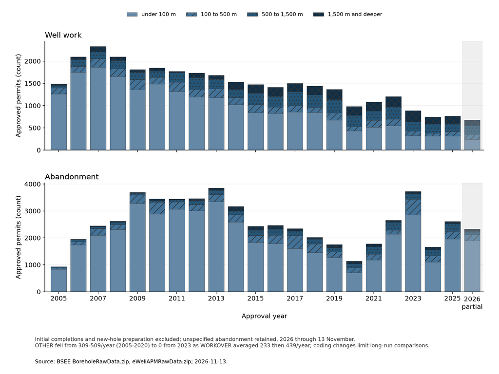

Figure 3. Approved permits to modify, by water depth

1. Approved permits to modify existing wells, counted by approval year and the well's water depth. Initial completions and new-hole preparation are excluded; abandonment of unstated type is kept. 2026 runs to 13 November.

2. From 2021, the feed moves well work from the OTHER code to WORKOVER; part of the fall in well work after 2020 reflects that change, and the early years have incomplete electronic coverage.

3. Data: counts_by_year_band_group.csv, rates.csv.

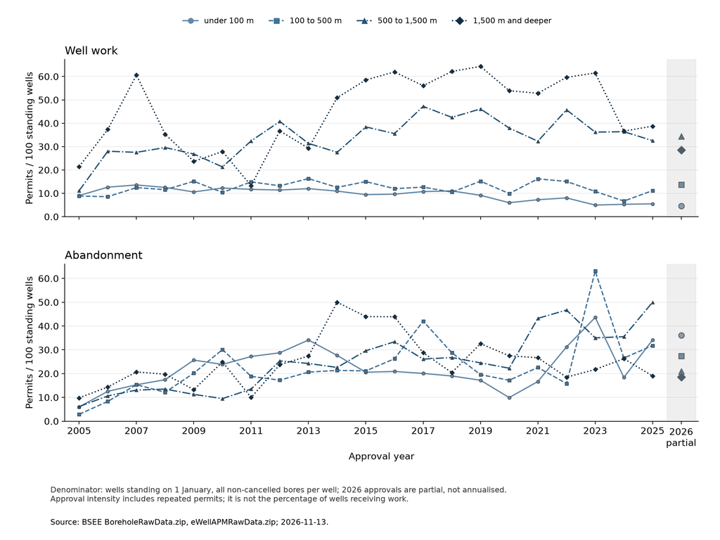

Figure 4. Approvals per 100 standing wells

1. Approvals in a year divided by the wells standing on 1 January of that year, per 100 wells. Wells first drilled during the year can add approvals but not stock, so this is a rate of approvals against the opening stock, not the share of wells worked on.

2. Data: rates.csv, standing_wells.csv; light and heavy by year: intervention_weight_by_year.csv.

### What the rate means

Figure 4 asks how often a standing well gets an approval in a year. A rate of 38.7 at 1,500 m and deeper in 2025 means about 0.4 intervention approvals for every standing deepwater well; 5.5 on the shelf means about one for every 18 standing shelf wells. The rate takes out the shrinking number of wells: 16,124 stood on 1 January 2005 and 7,636 on 1 January 2025.

- **Up or down?** Per standing well, intervention held in a narrow band for years and has been lower since 2023: 11.9 to 14.8 approvals per 100 standing wells a year from 2006 to 2019, 9.4 to 10.5 from 2023 to 2025. Part of the step down is the coding change in note 2 of Figure 3.
- **Light or heavy?** Light work is about twice as frequent as heavy work, and both are lower in 2023-2025 than in 2014-2019 (Appendix C).
- **Deeper water, more work per well.** The 2025 rate rises with depth (under 100 m: 5.5; 100 to 500 m: 11.2; 500 to 1,500 m: 32.6; 1,500 m and deeper: 38.7).
- **Abandonment** ran at 34.2 approvals per 100 standing wells in 2025, against 10.0 for interventions.

Figure 5 shows which units the 2025 approvals name, by water depth.

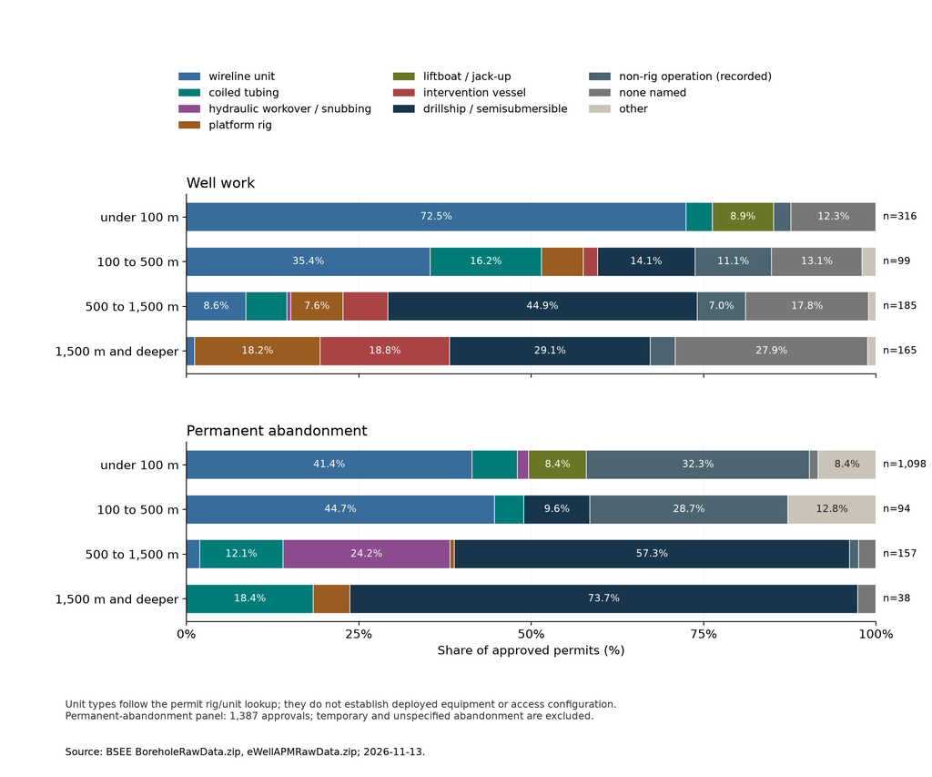

Figure 5. Units named on 2025 approvals, by depth

1. Share of 2025 approvals by the unit type the permit names, through the regulator's rig lookup; a named unit is not proof of the unit used.

2. Data: unit_type_shares.csv.

## 4. Cost per intervention, by access type

Cost follows how the well is reached, not depth alone: a dry-tree platform well can be worked from a rigless spread or casing jacks, a subsea well needs a vessel, a drillship or a semisubmersible. Figure 6 gives our low, base and high scenarios per event (2015 dollars; method in Appendix B).

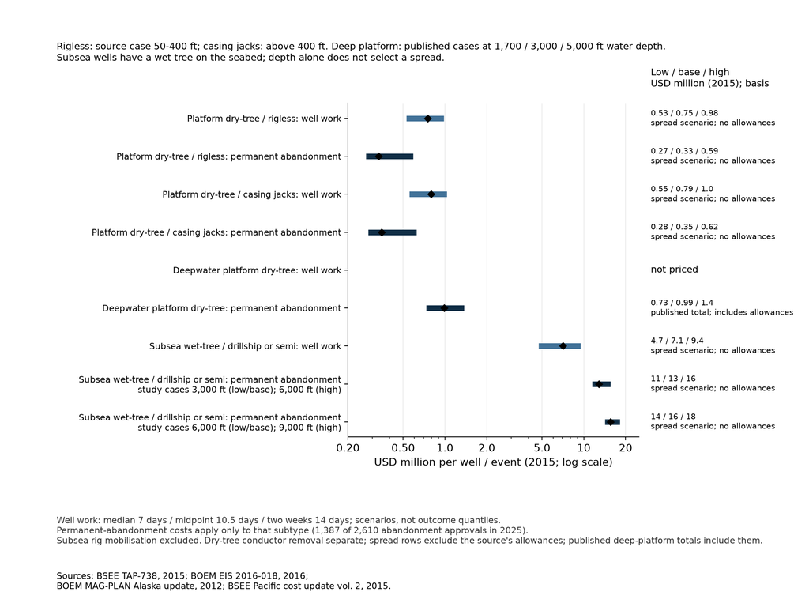

Figure 6. Cost per event, by well and access type

1. Scenario costs per event in USD million (2015), two significant figures; spread rows exclude the source's allowances, the deep-platform row is a published total that includes them.

2. Rig mobilisation is excluded from the drillship or semisubmersible rows (TAP-738, p. 8-18), not assumed free; mobilisation is added only for the platform spreads: the rigless case, from TAP-738 Table 8-2, and the casing-jack case, which borrows it.

3. Data: cost_table.csv.

## 5. Abandonment

This article shows abandonment only as counts and rates. The next article covers it in the same depth: why wells are left temporarily abandoned, how long they stay so, and what permanent abandonment costs.

## Charts and data

- Figure 1: [PNG](https://github.com/vamseeachanta/worldenergydata/blob/32e79fe83fa9fd5c58012ada1ecc05d2da21d590/examples/bsee/interventions_by_depth/output/05_well_life.png) · [SVG](https://github.com/vamseeachanta/worldenergydata/blob/32e79fe83fa9fd5c58012ada1ecc05d2da21d590/examples/bsee/interventions_by_depth/output/05_well_life.svg) · data life_cycle_life_histogram.csv
- Figure 2: [PNG](https://github.com/vamseeachanta/worldenergydata/blob/32e79fe83fa9fd5c58012ada1ecc05d2da21d590/examples/bsee/interventions_by_depth/output/06_well_life_stages.png) · [SVG](https://github.com/vamseeachanta/worldenergydata/blob/32e79fe83fa9fd5c58012ada1ecc05d2da21d590/examples/bsee/interventions_by_depth/output/06_well_life_stages.svg) · data life_cycle_stage_reach.csv
- Figure 3: [PNG](https://github.com/vamseeachanta/worldenergydata/blob/32e79fe83fa9fd5c58012ada1ecc05d2da21d590/examples/bsee/interventions_by_depth/output/01_approved_interventions.png) · [SVG](https://github.com/vamseeachanta/worldenergydata/blob/32e79fe83fa9fd5c58012ada1ecc05d2da21d590/examples/bsee/interventions_by_depth/output/01_approved_interventions.svg) · data counts_by_year_band_group.csv
- Figure 4: [PNG](https://github.com/vamseeachanta/worldenergydata/blob/32e79fe83fa9fd5c58012ada1ecc05d2da21d590/examples/bsee/interventions_by_depth/output/02_rates_per_standing_well.png) · [SVG](https://github.com/vamseeachanta/worldenergydata/blob/32e79fe83fa9fd5c58012ada1ecc05d2da21d590/examples/bsee/interventions_by_depth/output/02_rates_per_standing_well.svg) · data rates.csv
- Figure 5: [PNG](https://github.com/vamseeachanta/worldenergydata/blob/32e79fe83fa9fd5c58012ada1ecc05d2da21d590/examples/bsee/interventions_by_depth/output/04_unit_types_by_depth.png) · [SVG](https://github.com/vamseeachanta/worldenergydata/blob/32e79fe83fa9fd5c58012ada1ecc05d2da21d590/examples/bsee/interventions_by_depth/output/04_unit_types_by_depth.svg) · data unit_type_shares.csv
- Figure 6: [PNG](https://github.com/vamseeachanta/worldenergydata/blob/32e79fe83fa9fd5c58012ada1ecc05d2da21d590/examples/bsee/interventions_by_depth/output/03_cost_per_event.png) · [SVG](https://github.com/vamseeachanta/worldenergydata/blob/32e79fe83fa9fd5c58012ada1ecc05d2da21d590/examples/bsee/interventions_by_depth/output/03_cost_per_event.svg) · data cost_table.csv

To try it out or adapt the analysis, see reusable prompt.

If you have run your own analysis, see a way to improve this one, or have an idea for a future issue, write to support@aceengineer.com. We read every reply and credit the ideas we use and provide results we obtained.

Prepared: Petroleum Engineer Deckhand, Data Analyst Deckhand. Checked: Editor Deckhand. Approved: Vamsee Achanta (pending, C6 review copy r4).

## References

1. BOEM (2016). [Gulf of Mexico OCS Oil and Gas Lease Sales 2017-2022, Final EIS, Volume I](https://www.boem.gov/sites/default/files/environmental-stewardship/Environmental-Assessment/NEPA/BOEM-EIS-2016-018-v1.pdf), OCS EIS/EA BOEM 2016-018. Section 3.1.3.5, pp. 3-37 and 3-38.
2. BSEE / ICF International (July 2015). [Decommissioning Methodology and Cost Evaluation](https://www.bsee.gov/sites/bsee.gov/files/tap-technical-assessment-program/738aa1.pdf), TAP-738. Pages 5-21, 6-9 and 8-12 to 8-19.
3. BOEM / Northern Economics (May 2012). [MAG-PLAN Alaska Update](https://espis.boem.gov/final%20reports/5179.pdf), BOEM 2011-059. Section 3.5.5.4, p. 108.
4. BSEE / TSB Offshore (February 2015). [Decommissioning Cost Update for Pacific OCS Region Facilities, Volume 2](https://www.bsee.gov/sites/bsee.gov/files/technology-assessment-program-tap/735ab.pdf). Appendix 2, p. A-2 (rigless durations behind Figure 6).
5. BSEE Data Center. [Raw data downloads](https://www.data.bsee.gov/Main/RawData.aspx): BoreholeRawData.zip, eWellAPMRawData.zip, eWellEORRawData.zip and eWellWARRawData.zip, files of 13 November 2026; [permit to modify (eWellAPM) query](https://www.data.bsee.gov/Well/eWellAPM/Default.aspx), Approved Date column.

#GulfOfMexico #OffshoreWells #WellIntervention #WellLifeCycle #PetroleumEngineering #OpenData

## Appendix A. Counting rules

1. **Wells and life.** One well is one API10 number in BSEE's borehole file, region G, with cancelled bores removed. A well starts at the earliest spud date of its bores. It ends when every bore that is not superseded (status ST or BP) is permanently abandoned (PA) with a date; the end is the latest of those dates. Otherwise it stands at 13 November 2026. Development (D) and exploration (E) follow the well type of the original hole (suffix ST00BP00).
2. **Drilling.** Each bore with a spud date: the original hole and each sidetrack or bypass. Permits that prepare new hole (PLUGBACK, sidetrack, bypass or deepen) are excluded from the permit counts so that drilling is not counted twice.
3. **Permits.** BSEE's permit table (eWellAPM) has no separate approval-status field. Assumed, to be confirmed: every row is an approved permit, and its ACC_STATUS_DATE (the Approved Date column of BSEE's permit query) is the approval date; a row without a valid date is not counted. One approved permit to modify (one submission ID) is one event. WORKOVER, ENHANCE, COMP with ZONE, OTHER, INFORM and UTIL are interventions (well work). ABANDON with PERMABAN is permanent abandonment, else with TEMPABAN temporary abandonment, else of unstated type. COMP without ZONE (initial completion) is excluded. Approvals from 2005 to 13 November 2026 are counted; the feed begins part-way through 2004.
4. **Light or heavy.** From the unit type the permit names (rig ID joined to the regulator's rig lookup). Light: wireline (WL), coiled tubing (CT), intervention vessel (WI), liftboat (LB), recorded non-rig operation (NR). Heavy: hydraulic workover or snubbing unit (HW, SB), platform rig (PF), jack-up rig (JU), drillship or semisubmersible (DS, SS, SD). Not classified: no unit named, or another type (barge, submersible, unmatched). These groups keep the unit categories of the permit counts, except that the combined "liftboat / jack-up" category is divided by its two source codes. Mapping: intervention_weight_mapping.csv.
5. **Water depth** is the well's depth in feet times 0.3048, in four bands: under 100 m, 100 to 500 m, 500 to 1,500 m, and 1,500 m and deeper.
6. **Standing wells** on 1 January use the same start and end rule as item 1.

## Appendix B. Cost method

Our spread scenarios multiply a published day rate by low, base and high durations. The rigless platform spread is USD 64,530 a day, derived from a TAP-738 P&A spread (Table 8-2: USD 225,856 over 84 hours) on p. 8-12; casing jacks USD 68,424 a day (Table 8-3, p. 8-14); a drillship or semisubmersible USD 674,600 a day (p. 8-18). Rig mobilisation is excluded from the drillship or semisubmersible rows (TAP-738, p. 8-18), not assumed free; mobilisation is added only for the platform spreads: the rigless case, from TAP-738 Table 8-2, and the casing-jack case, which borrows it. Well-work durations are 7, 10.5 and 14 days (BOEM 2016-018, p. 3-37: a Gulf median of 7 days, within a range of 1 day to several months; one to two weeks from the BOEM Alaska update, 2012, p. 108). On these inputs a light well-work job on a shelf platform costs USD 0.53 to 0.98 million and a subsea job from a drillship or semisubmersible USD 4.7 to 9.4 million. The deepwater dry-tree abandonment row is TAP-738's published per-well total (Table 8-4, p. 8-15). Costs are 2015 dollars, not escalated, and are scenarios, not bids. The full table, every input and its source page are in the [full study](https://github.com/vamseeachanta/worldenergydata/tree/24744b528298f26c51bfce4cb3b66fa4f676eb02/examples/bsee/interventions_by_depth) (cost_table.csv).

## Appendix C. Detail behind sections 2 and 3

- **Heavy work.** 59% of development wells drilled since 2005 have had at least one heavy intervention approved; development wells still standing from that group are a median 14.4 years old. Two in three exploration wells drilled since 2005 are already permanently abandoned, most within a year of spud.
- **Interventions by depth.** In 2025, the 765 intervention approvals were under 100 m: 316; 100 to 500 m: 99; 500 to 1,500 m: 185; 1,500 m and deeper: 165.
- **Count against rate.** The count of intervention approvals fell further than the rate, from 2,099 in 2006 to 765 in 2025, mostly because there are fewer wells.
- **Light or heavy.** From 2014, at least three in four intervention approvals name a unit that can be classified (82% in 2025). Since then light work has run at 5.4 to 8.5 approvals per 100 standing wells a year and heavy work at 2.5 to 4.8. Light work averaged 7.6 in 2014-2019 and 5.6 in 2023-2025; heavy work averaged 3.8 and 2.8.
- **Depth.** Deepwater wells are fewer and more often subsea, and the operators' own estimates on their permits put a well-work job at a median 14 days at 1,500 m and deeper against 3 under 100 m.

## Appendix D. Reusable prompt

This prompt rebuilds the life of every Gulf of Mexico well and the intervention counts from BSEE's public raw data, and adapts them to your own field or depth range. To have a study of your own wells done for you instead, see below.

### What you need to run this

- Data required: BSEE raw data, BoreholeRawData.zip and eWellAPMRawData.zip (and eWellEORRawData.zip and eWellWARRawData.zip for the cross-checks), from data.bsee.gov.
- Data required to adapt: a list of API numbers, or a lease, area or depth range.
- Paid or behind an account: nothing.
- Changes over time: BSEE refreshes the files daily, so a new download gives slightly different recent counts.

### Reproduce the published result

```
Using the worldenergydata repository at commit 24744b528298f26c51bfce4cb3b66fa4f676eb02, folder examples/bsee/interventions_by_depth:
download the four BSEE archives with download_data.py --snapshot 2026-11-13
(or use a later snapshot and expect small changes in recent years), then run
count_interventions.py, well_life_cycle.py, build_cost_basis.py, estimate_costs.py,
plot_charts.py, plot_life_cycle.py and build_article.py. Check that
output/life_cycle_reconciliation.csv shows the same published and counted totals,
and that 2025 gives 765 intervention and 2,610 abandonment approvals.
```

### Adapt it to your project

```
Filter the borehole and permit tables to your wells before the life-cycle step.
Report, per well: life in years, bores drilled, light and heavy interventions,
temporary and permanent abandonment approvals, with the counting rules of Appendix A.
Keep approvals separate from completed jobs, and state the unit rule you use.
```

Data set: BSEE Data Center raw well data (public), files of 13 November 2026.

To have a study of your own wells done for you, write to support@aceengineer.com.